# Week 6 Practice

BDS

July 2, 2018

```r
library(dplyr)

library(psych)

library(lme4)

library(ggplot2)
```

The data for this week, while not too complicated, can throw you for a loop if you are not paying attention to your file extensions and/or not taking a quick look at the file!

```r
readLines("C://Users/berry2006/Documents/projects/courses/bds/exerciseData/week06.tab")[1]
```

```
## [1] "\"id\" \"team\" \"manager\" \"jobTasksSDSA\" \"jobBalanceSDSA\" \"jobPaySDSA\" \"jobRecognitionSDSA\" \"jobAdvancementSDSA\" \"jobCoworkersSDSA\" \"jobManagementSDSA\" \"salary\""
```

Our delimiter is definitely some type of white space, so we can just use the default from read.table.

```r
week6 = read.table("C://Users/berry2006/Documents/projects/courses/bds/exerciseData/week06.tab")
```

Let’s take a quick peak at our data:

```r
summary(week6)
```

```
##        id            team        manager     jobTasksSDSA
##  A103R  :   1   DSI    : 64   Y9641W : 99   Min.   :1.000
##  A105D  :   1   Ethics :199   X7645X : 95   1st Qu.:2.000
##  A105O  :   1   Finance:441   Y3553W : 95   Median :4.000
##  A126C  :   1   Health :239   Y4468Y : 91   Mean   :4.004
##  A129A  :   1   R&D    :441   X8066X : 88   3rd Qu.:6.000
##  A163W  :   1                 Z2464Y : 88   Max.   :7.000
##  (Other):1378                 (Other):828
##  jobBalanceSDSA    jobPaySDSA    jobRecognitionSDSA jobAdvancementSDSA
##  Min.   :1.000   Min.   :1.000   Min.   :1.000      Min.   :1.00
##  1st Qu.:2.000   1st Qu.:4.000   1st Qu.:4.000      1st Qu.:4.00
##  Median :4.000   Median :6.000   Median :5.000      Median :5.00
##  Mean   :4.069   Mean   :5.178   Mean   :5.173      Mean   :5.21
##  3rd Qu.:6.000   3rd Qu.:7.000   3rd Qu.:7.000      3rd Qu.:7.00
##  Max.   :7.000   Max.   :7.000   Max.   :7.000      Max.   :7.00
##
##  jobCoworkersSDSA jobManagementSDSA     salary
##  Min.   :1.000    Min.   :0.000     Min.   : 45002
##  1st Qu.:4.000    1st Qu.:4.000     1st Qu.: 53555
##  Median :6.000    Median :5.000     Median : 64990
##  Mean   :5.259    Mean   :5.174     Mean   : 76578
##  3rd Qu.:7.000    3rd Qu.:7.000     3rd Qu.: 93051
##  Max.   :7.000    Max.   :7.000     Max.   :171648
##                   NA's   :212
```

Excellent! We have some new variables to explore!

Since we have already done the work of creating factors in previous weeks, let’s get right to getting those scores into our data:

```r
week6FA = week6 %>%
  select(starts_with("job")) %>%
  fa(., nfactors = 2, rotate = "promax")


week6 = week6 %>%
  mutate(jobScore = week6FA$scores[, "MR1"],
         interpersonalScore = week6FA$scores[, "MR2"])

summary(week6)
```

```
##        id            team        manager     jobTasksSDSA
##  A103R  :   1   DSI    : 64   Y9641W : 99   Min.   :1.000
##  A105D  :   1   Ethics :199   X7645X : 95   1st Qu.:2.000
##  A105O  :   1   Finance:441   Y3553W : 95   Median :4.000
##  A126C  :   1   Health :239   Y4468Y : 91   Mean   :4.004
##  A129A  :   1   R&D    :441   X8066X : 88   3rd Qu.:6.000
##  A163W  :   1                 Z2464Y : 88   Max.   :7.000
##  (Other):1378                 (Other):828
##  jobBalanceSDSA    jobPaySDSA    jobRecognitionSDSA jobAdvancementSDSA
##  Min.   :1.000   Min.   :1.000   Min.   :1.000      Min.   :1.00
##  1st Qu.:2.000   1st Qu.:4.000   1st Qu.:4.000      1st Qu.:4.00
##  Median :4.000   Median :6.000   Median :5.000      Median :5.00
##  Mean   :4.069   Mean   :5.178   Mean   :5.173      Mean   :5.21
##  3rd Qu.:6.000   3rd Qu.:7.000   3rd Qu.:7.000      3rd Qu.:7.00
##  Max.   :7.000   Max.   :7.000   Max.   :7.000      Max.   :7.00
##
##  jobCoworkersSDSA jobManagementSDSA     salary          jobScore
##  Min.   :1.000    Min.   :0.000     Min.   : 45002   Min.   :-1.85230
##  1st Qu.:4.000    1st Qu.:4.000     1st Qu.: 53555   1st Qu.:-1.05405
##  Median :6.000    Median :5.000     Median : 64990   Median :-0.06863
##  Mean   :5.259    Mean   :5.174     Mean   : 76578   Mean   :-0.10957
##  3rd Qu.:7.000    3rd Qu.:7.000     3rd Qu.: 93051   3rd Qu.: 0.91657
##  Max.   :7.000    Max.   :7.000     Max.   :171648   Max.   : 1.23033
##                   NA's   :212                        NA's   :212
##  interpersonalScore
##  Min.   :-1.98031
##  1st Qu.:-1.02366
##  Median : 0.04607
##  Mean   :-0.03625
##  3rd Qu.: 1.01495
##  Max.   : 1.31106
##  NA's   :212
```

Purely because we can, let’s take a look at some possible relationships:

[figure not shown]

```r
week6 %>%
  select(jobScore, interpersonalScore, salary) %>%
  cor() %>%
  ggcorrplot::ggcorrplot()
```

Not much going on in the way of correlations, but let’s run a quick model.

```r
slim = lm(jobScore ~ salary, data = week6)
```

We would have known that there was not much going on if we would have looked a visualization first (I really cannot fully support the notion of abonding a hypothesis just because a clear pattern does not emerge through viz):

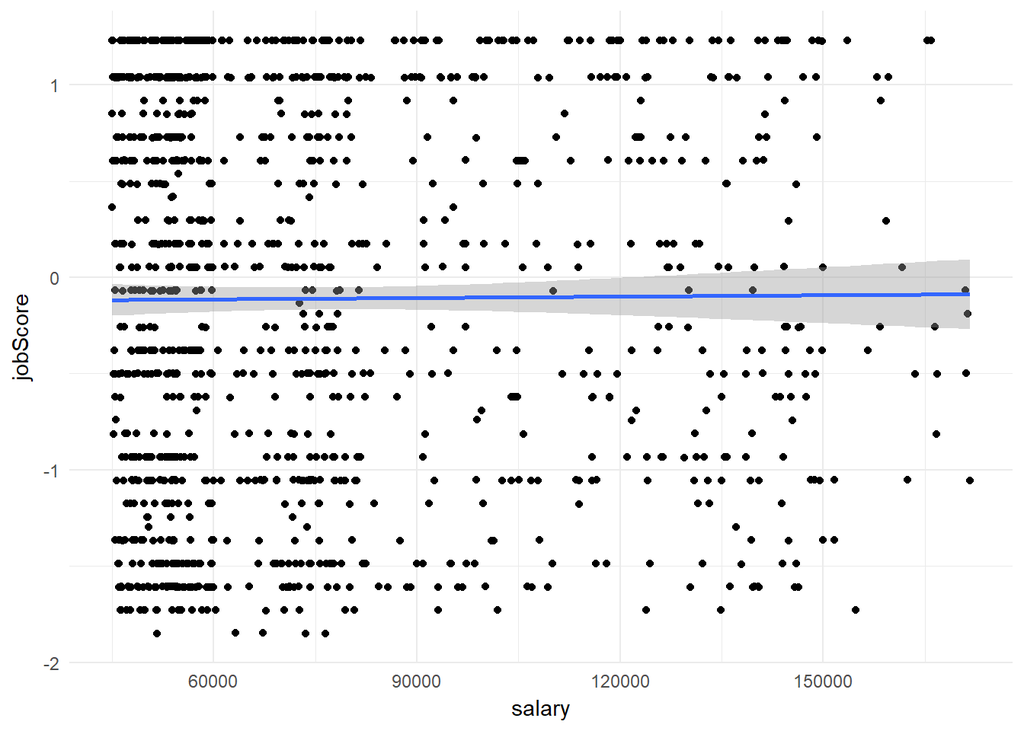

```r
ggplot(week6, aes(salary, jobScore)) +
  geom_point() +
  geom_smooth(method = "lm") +
  theme_minimal()
```

Salary was not the only new variable in the data, so let’s look at the other two.

```r
summary(week6$team)
```

```
##     DSI  Ethics Finance  Health     R&D
##      64     199     441     239     441
```

```r
summary(week6$manager)
```

```
##  I511L V4497X V7487V V8472W W2205Z W7742X W8102W X3607X X7645X X8022Z
##     12     85     80     52     61     68     79     85     95     70
## X8066X Y3553W Y4468Y Y7685W Y9641W Z2464Y Z4101Z Z7298V
##     88     95     91     81     99     88     80     75
```

```r
week6 %>%
  group_by(team, manager) %>%
  summarize(n = n())
```

```
## # A tibble: 18 x 3
## # Groups:   team [?]
##    team    manager     n
##    <fct>   <fct>   <int>
##  1 DSI     I511L      12
##  2 DSI     V8472W     52
##  3 Ethics  W2205Z     61
##  4 Ethics  W7742X     68
##  5 Ethics  X8022Z     70
##  6 Finance X7645X     95
##  7 Finance Y4468Y     91
##  8 Finance Y7685W     81
##  9 Finance Y9641W     99
## 10 Finance Z7298V     75
## 11 Health  V7487V     80
## 12 Health  W8102W     79
## 13 Health  Z4101Z     80
## 14 R&D     V4497X     85
## 15 R&D     X3607X     85
## 16 R&D     X8066X     88
## 17 R&D     Y3553W     95
## 18 R&D     Z2464Y     88
```

It appears that each team has a few different managers within. There are other things that we could learn, but I will let you do that exploration on your own!

Maybe we should visualize some things:

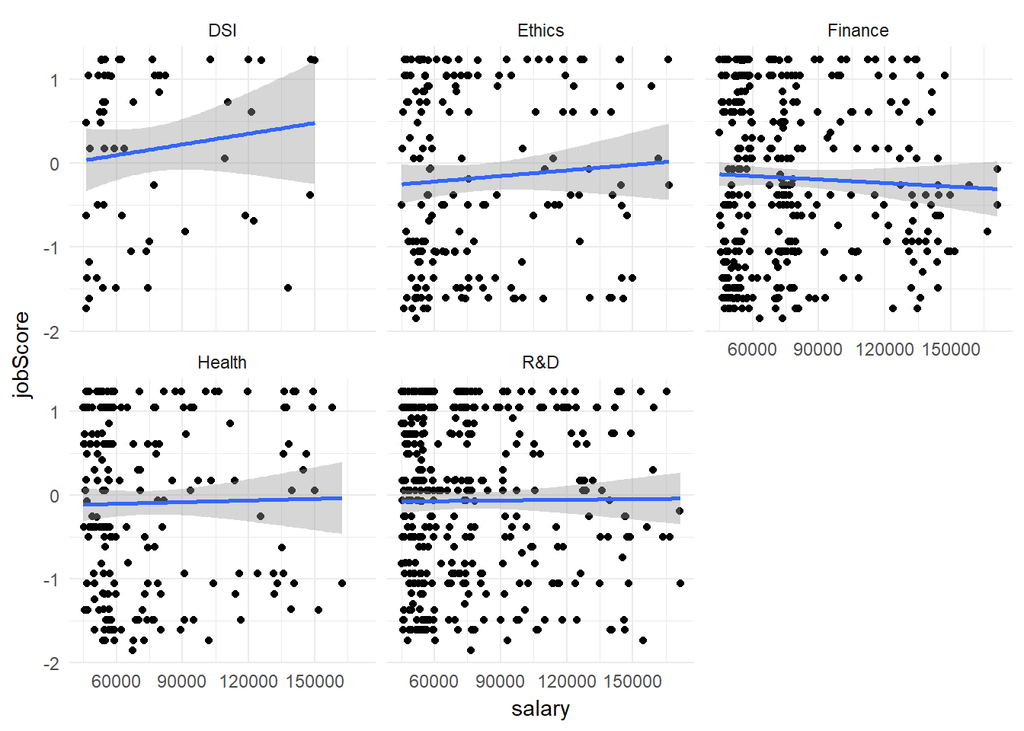

```r
ggplot(week6, aes(salary, jobScore)) +
  geom_point() +
  geom_smooth(method = "lm") +
  facet_wrap(~ team) +
  theme_minimal()
```

That is more interesting.

What about this:

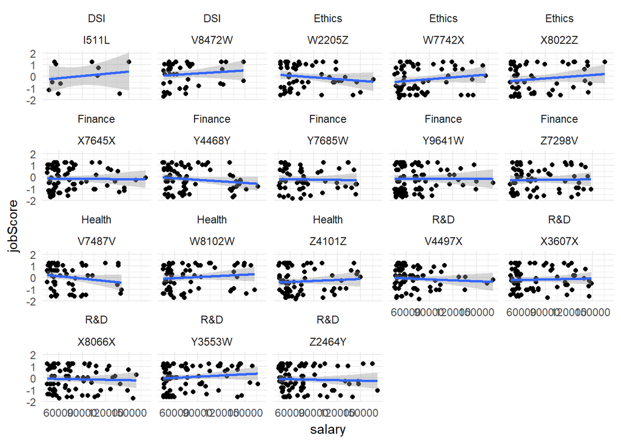

```r
ggplot(week6, aes(salary, jobScore)) +
  geom_point() +
  geom_smooth(method = "lm") +
  facet_wrap(team ~ manager) +
  theme_minimal()
```

That gives us a lot of information.

Since we know that we have a multilevel arrangment, let’s wander down the mixed model path.

```r
lmerTeam = lmer(jobScore ~ salary + (1|team), data = week6)

summary(lmerTeam)
```

```
## Linear mixed model fit by REML ['lmerMod']
## Formula: jobScore ~ salary + (1 | team)
##    Data: week6
##
## REML criterion at convergence: 3342.3
##
## Scaled residuals:
##     Min      1Q  Median      3Q     Max
## -1.7704 -0.9301  0.0400  1.0111  1.3770
##
## Random effects:
##  Groups   Name        Variance Std.Dev.
##  team     (Intercept) 0.001583 0.03979
##  Residual             0.988133 0.99405
## Number of obs: 1172, groups:  team, 5
##
## Fixed effects:
##               Estimate Std. Error t value
## (Intercept) -1.249e-01  7.948e-02  -1.572
## salary       2.465e-07  9.287e-07   0.265
##
## Correlation of Fixed Effects:
##        (Intr)
## salary -0.897
## fit warnings:
## Some predictor variables are on very different scales: consider rescaling
```

We can also look at the effect of manager:

```r
lmerManager = lmer(jobScore ~ salary + (1|manager), data = week6)

summary(lmerManager)
```

```
## Linear mixed model fit by REML ['lmerMod']
## Formula: jobScore ~ salary + (1 | manager)
##    Data: week6
##
## REML criterion at convergence: 3342.4
##
## Scaled residuals:
##      Min       1Q   Median       3Q      Max
## -1.75563 -0.93709  0.04749  1.02317  1.38039
##
## Random effects:
##  Groups   Name        Variance Std.Dev.
##  manager  (Intercept) 0.001808 0.04253
##  Residual             0.987581 0.99377
## Number of obs: 1172, groups:  manager, 18
##
## Fixed effects:
##               Estimate Std. Error t value
## (Intercept) -1.279e-01  7.775e-02  -1.645
## salary       2.444e-07  9.289e-07   0.263
##
## Correlation of Fixed Effects:
##        (Intr)
## salary -0.918
## fit warnings:
## Some predictor variables are on very different scales: consider rescaling
```

Finally, we can look at how they are nested:

```r
lmerTeamManager = lmer(jobScore ~ salary + (1|team) + (1|team:manager), data = week6)

summary(lmerTeamManager)
```

```
## Linear mixed model fit by REML ['lmerMod']
## Formula: jobScore ~ salary + (1 | team) + (1 | team:manager)
##    Data: week6
##
## REML criterion at convergence: 3342.3
##
## Scaled residuals:
##      Min       1Q   Median       3Q      Max
## -1.76909 -0.93075  0.04234  1.01324  1.37990
##
## Random effects:
##  Groups       Name        Variance  Std.Dev.
##  team:manager (Intercept) 0.0008455 0.02908
##  team         (Intercept) 0.0013430 0.03665
##  Residual                 0.9875103 0.99374
## Number of obs: 1172, groups:  team:manager, 18; team, 5
##
## Fixed effects:
##               Estimate Std. Error t value
## (Intercept) -1.254e-01  7.944e-02  -1.579
## salary       2.482e-07  9.287e-07   0.267
##
## Correlation of Fixed Effects:
##        (Intr)
## salary -0.898
## fit warnings:
## Some predictor variables are on very different scales: consider rescaling
```